# MLRA Comparison

MLRA: 15, 18, 27, 35  
report version 2.0  
2023-03-07

This report is designed to provide statistical summaries of the environmental properties for one or more MLRA Summaries are based on raster data extracted from [fixed-density sampling of map unit polygons](http://ncss-tech.github.io/AQP/sharpshootR/sample-vs-population.html). [Percentiles](https://ncss-tech.github.io/soil-range-in-characteristics/why-percentiles.html) are used as robust metrics of distribution central tendency and spread.

### Modified Box and Whisker Plots

Whiskers extend from the 5th to 95th [percentiles](https://en.wikipedia.org/wiki/Percentile), the body represents the 25th through 75th percentiles, and the dot is the 50th percentile.

**Suggested usage:**

- Gauge overlap between map units in terms of boxes (25th-75th percentiles) and whiskers (5th-95th percentiles).
- Non-overlapping boxes are a strong indication that the central tendencies (of select raster data) differ.
- Distribution shape is difficult to infer from box and whisker plots, remember to cross-reference with density plots below.

#### PRISM

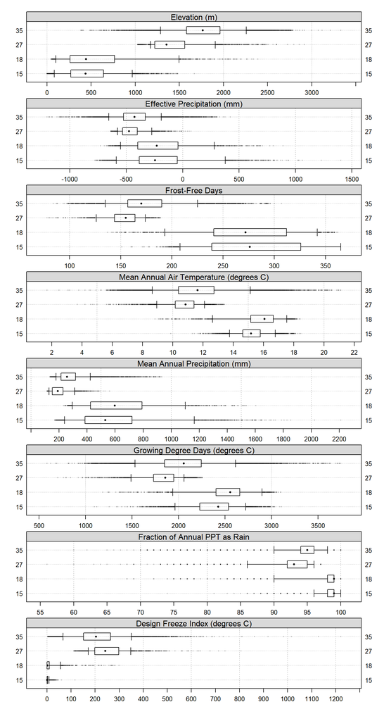

#### ISSR-800

Aggregate [soil properties](https://github.com/ncss-tech/ISSR-800/) developed from SSURGO/STATSGO at 800m resolution.

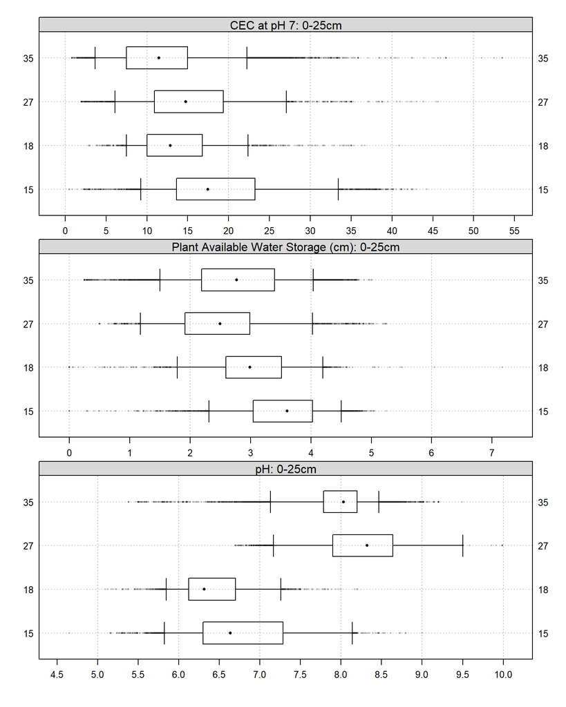

#### Gamma Spectroscopy

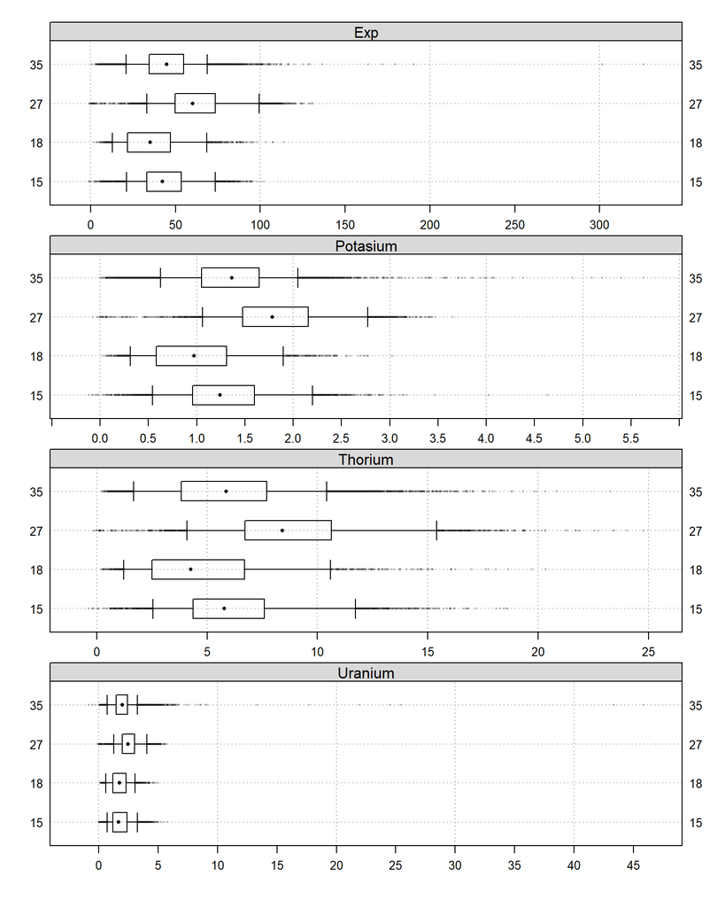

#### Population Density

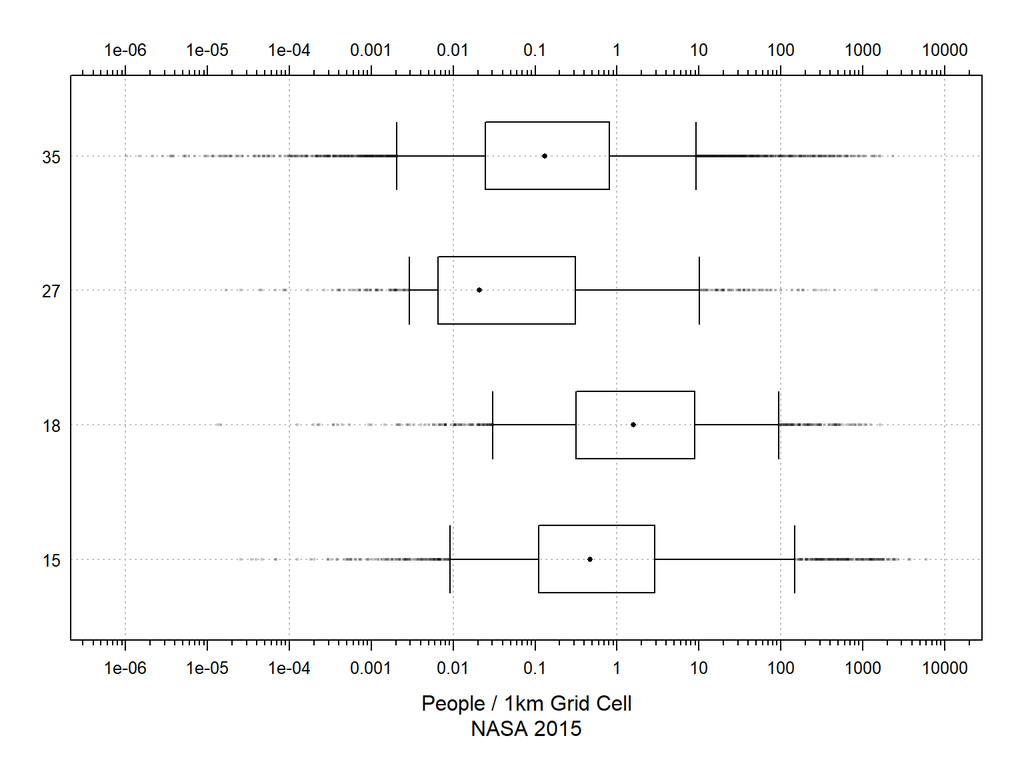

### Density Plots

These plots are a smooth alternative ([denisty estimation](https://en.wikipedia.org/wiki/Density_estimation)) to the classic “binned” ([histogram](https://en.wikipedia.org/wiki/Histogram)) approach to visualizing distributions. Peaks correspond to values that are most frequent within a data set. Each data set (ID / variable) are rescaled to {0,1} so that the y-axis can be interpreted as the “relative proportion of samples”. Note that density estimates are constrained to the range defined by the 1–99 percentiles.

**Suggested usage:**

- Density plots depict a more detailed summary of distribution shape.
- When making comparisons, be sure to look for:
  - multiple peaks
  - narrow peaks vs. wide “mounds”
  - short vs. long “tails”

#### PRISM

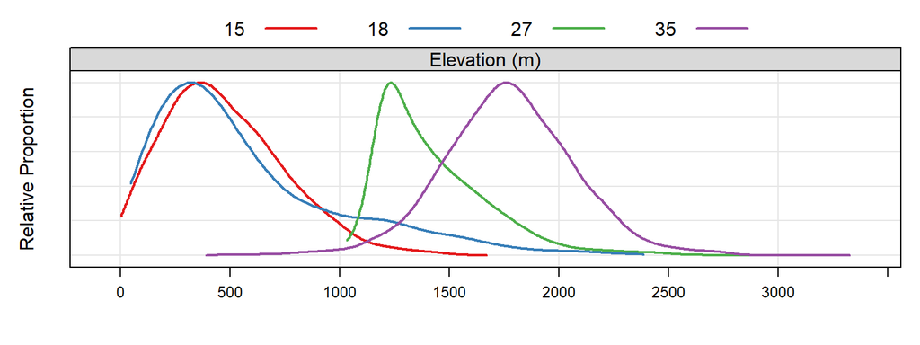

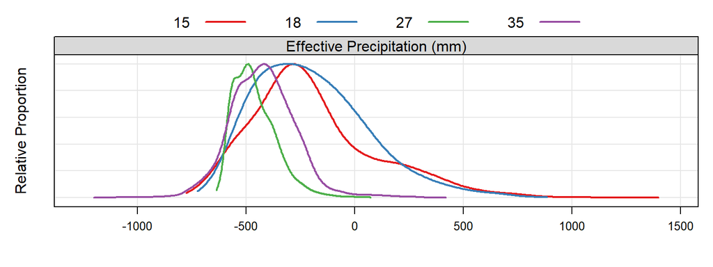

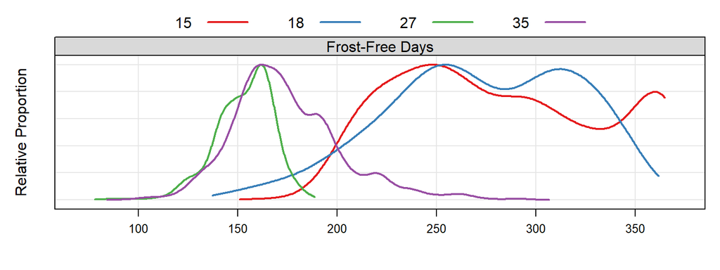

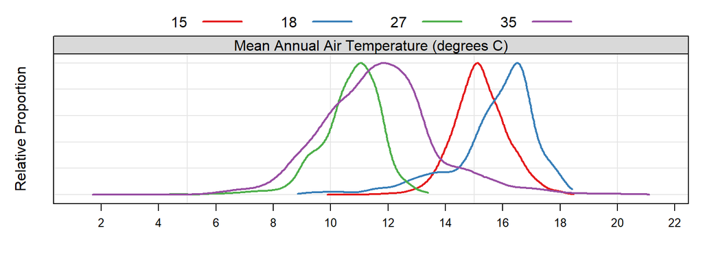

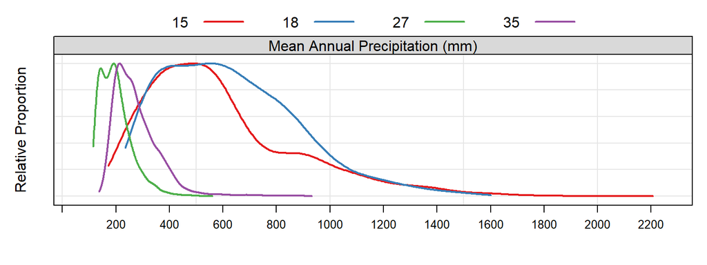

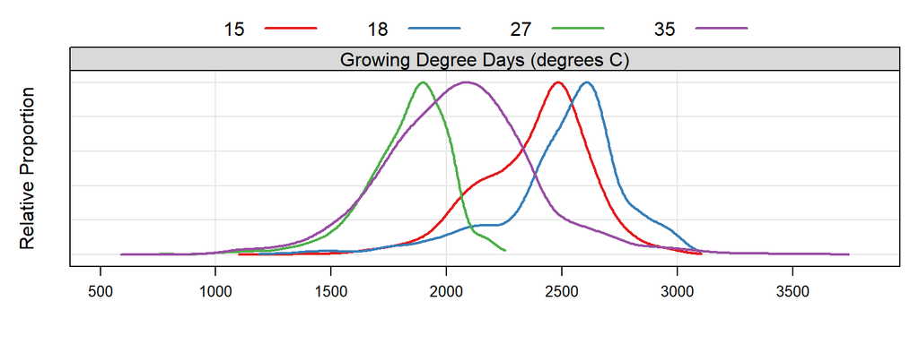

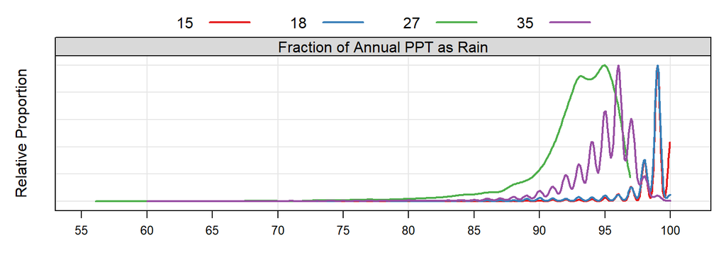

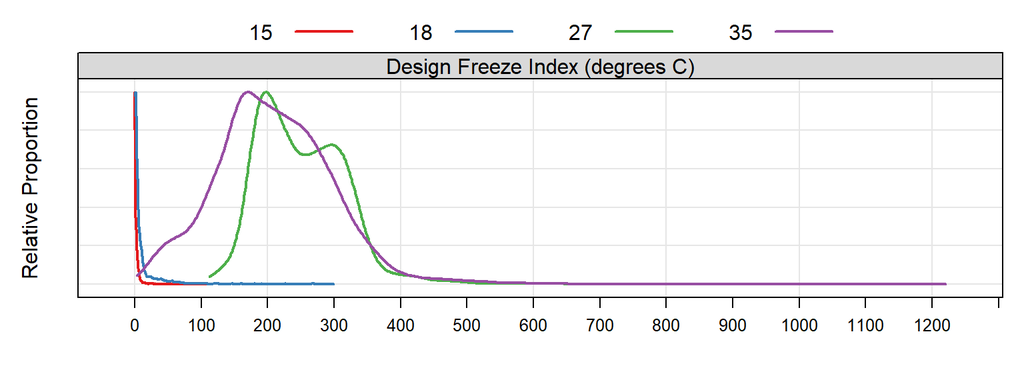

#### ISSR-800

Aggregate [soil properties](https://github.com/ncss-tech/ISSR-800/) developed from SSURGO/STATSGO at 800m resolution.

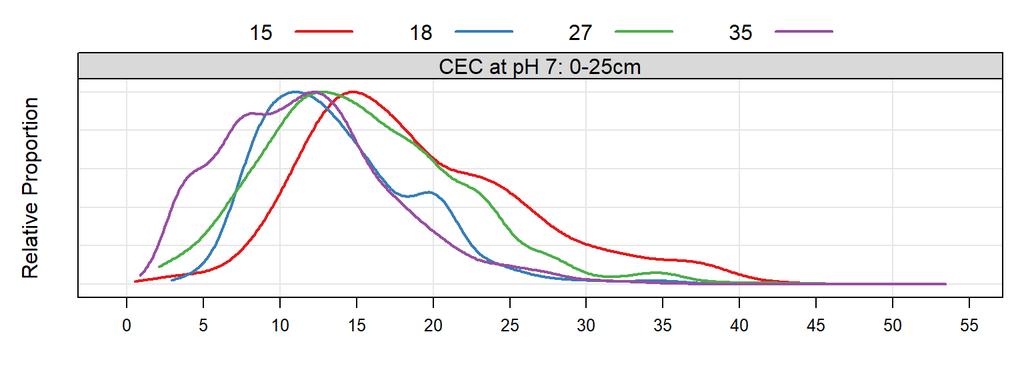

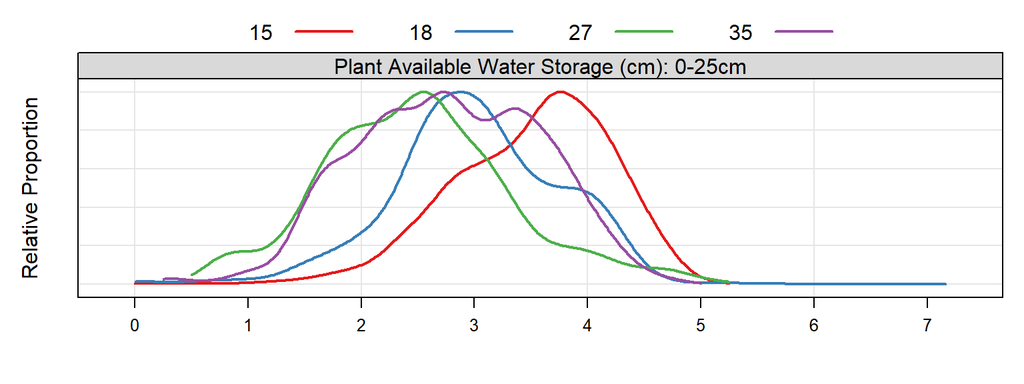

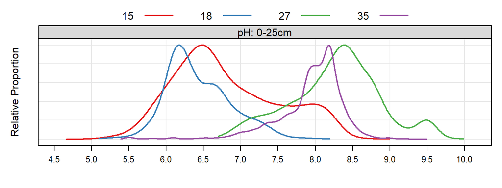

#### Gamma Spectroscopy

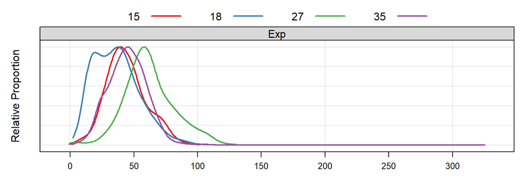

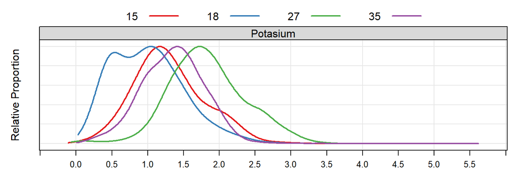

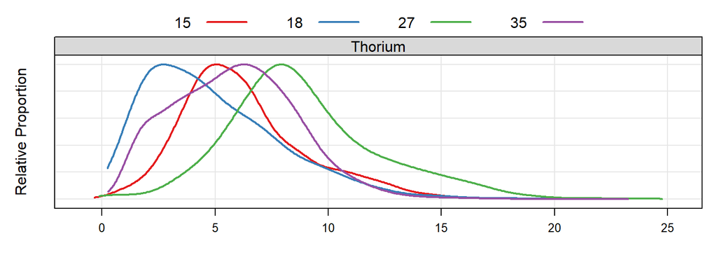

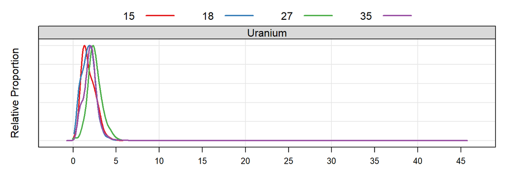

### Monthly Summaries

Median PPT vs. PET, bounded by 25th and 75th percentile.

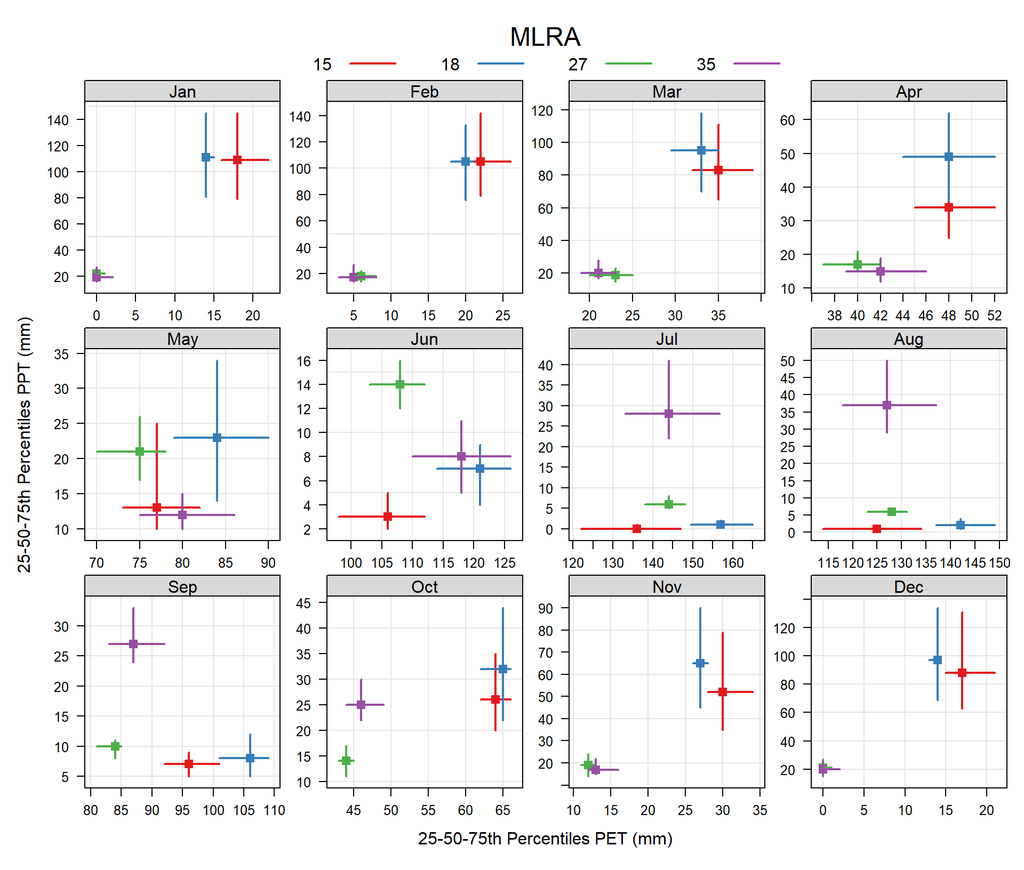

Modified box-whisker comparisons by month.

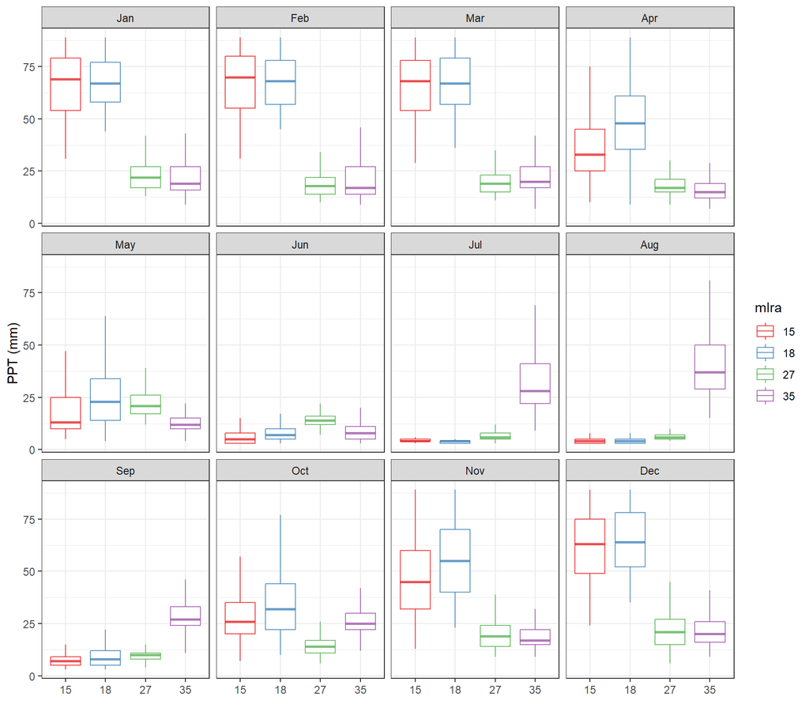

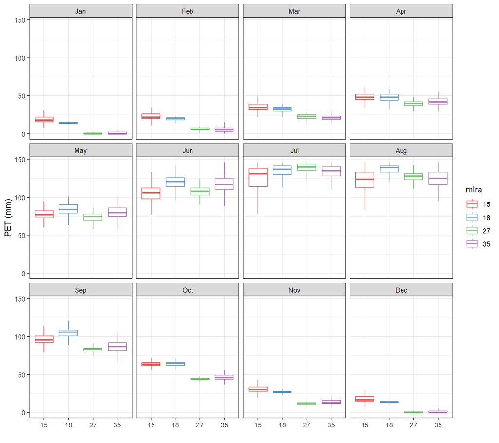

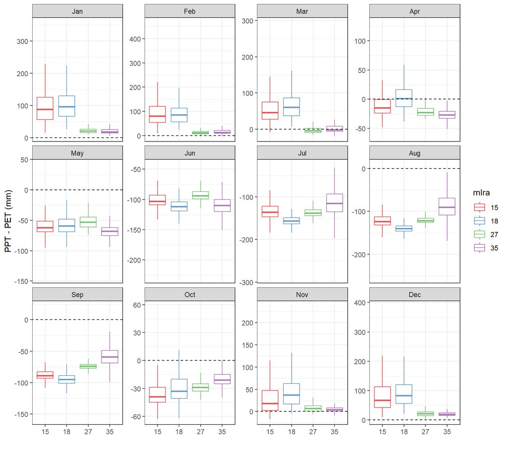

Monthly inter-quartile range.

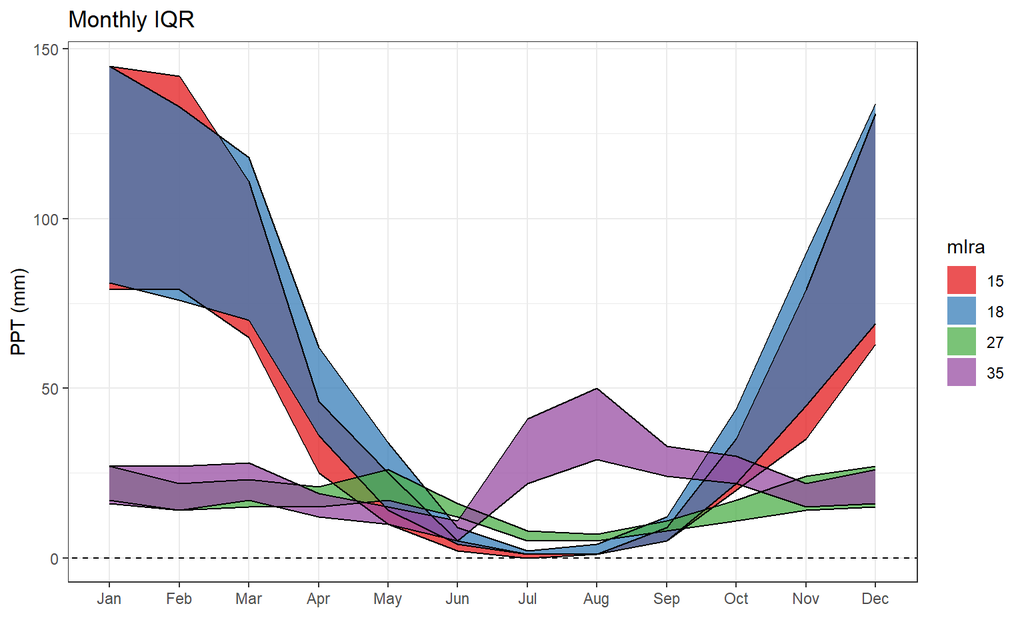

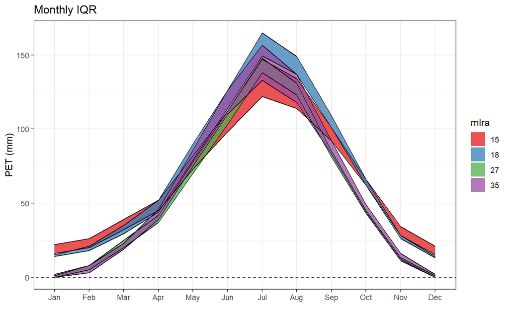

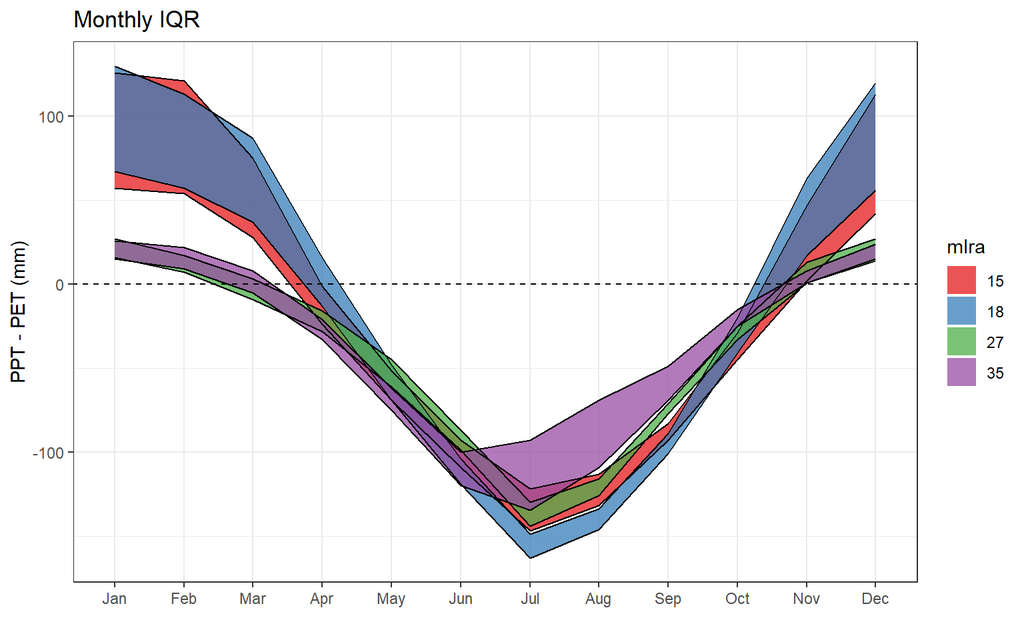

### Tabular Summaries

Table of select [percentiles](https://en.wikipedia.org/wiki/Percentile), by variable. In these tables, headings like “Q5” can be interpreted as the the “5th percentile”; 5% of the data are less than this value. The 50th percentile (“Q50”) is the median.

Median Values

| MLRA | Elevation (m) | Effective Precipitation (mm) | Frost-Free Days | Mean Annual Air Temperature (degrees C) | Mean Annual Precipitation (mm) | Growing Degree Days (degrees C) | Fraction of Annual PPT as Rain | Design Freeze Index (degrees C) |
| --- | --- | --- | --- | --- | --- | --- | --- | --- |
| 15 | 436 | -245.28 | 276 | 15.18 | 529 | 2428 | 99 | 0 |
| 18 | 442 | -229.67 | 272 | 16.07 | 597 | 2557 | 99 | 2 |
| 27 | 1356 | -476.25 | 155 | 10.85 | 190 | 1858 | 93 | 242 |
| 35 | 1767 | -426.54 | 170 | 11.64 | 257 | 2056 | 95 | 204 |

Elevation (m)

| MLRA | Q5 | Q10 | Q25 | Q50 | Q75 | Q90 | Q95 |
| --- | --- | --- | --- | --- | --- | --- | --- |
| 15 | 82 | 140 | 269 | 436 | 641 | 850 | 967.3 |
| 18 | 99 | 146 | 262 | 442 | 764 | 1229 | 1495.0 |
| 27 | 1174 | 1186 | 1222 | 1356 | 1562 | 1770 | 1906.8 |
| 35 | 1287 | 1404 | 1580 | 1767 | 1960 | 2148 | 2259.0 |

Effective Precipitation (mm)

| MLRA | Q5 | Q10 | Q25 | Q50 | Q75 | Q90 | Q95 |
| --- | --- | --- | --- | --- | --- | --- | --- |
| 15 | -588.16 | -525.98 | -384.38 | -245.28 | -48.40 | 241.25 | 378.35 |
| 18 | -549.78 | -501.15 | -397.52 | -229.67 | -41.76 | 143.77 | 279.67 |
| 27 | -576.57 | -569.79 | -533.59 | -476.25 | -401.17 | -330.62 | -274.62 |
| 35 | -654.56 | -595.77 | -523.71 | -426.54 | -331.65 | -243.04 | -190.22 |

Frost-Free Days

| MLRA | Q5 | Q10 | Q25 | Q50 | Q75 | Q90 | Q95 |
| --- | --- | --- | --- | --- | --- | --- | --- |
| 15 | 208 | 216 | 239 | 276 | 326 | 365 | 365 |
| 18 | 193 | 210 | 241 | 272 | 312 | 333 | 342 |
| 27 | 126 | 135 | 144 | 155 | 164 | 169 | 174 |
| 35 | 135 | 144 | 157 | 170 | 190 | 210 | 225 |

Mean Annual Air Temperature (degrees C)

| MLRA | Q5 | Q10 | Q25 | Q50 | Q75 | Q90 | Q95 |
| --- | --- | --- | --- | --- | --- | --- | --- |
| 15 | 13.75 | 14.08 | 14.63 | 15.18 | 15.79 | 16.45 | 16.78 |
| 18 | 12.64 | 13.56 | 15.16 | 16.07 | 16.66 | 17.17 | 17.55 |
| 27 | 8.94 | 9.31 | 10.17 | 10.85 | 11.41 | 11.81 | 12.10 |
| 35 | 8.65 | 9.29 | 10.39 | 11.64 | 12.73 | 14.05 | 15.13 |

Mean Annual Precipitation (mm)

| MLRA | Q5 | Q10 | Q25 | Q50 | Q75 | Q90 | Q95 |
| --- | --- | --- | --- | --- | --- | --- | --- |
| 15 | 238.7 | 287 | 386 | 529 | 721 | 1000 | 1165.30 |
| 18 | 295.0 | 326 | 424 | 597 | 791 | 958 | 1100.00 |
| 27 | 129.0 | 132 | 152 | 190 | 228 | 277 | 311.00 |
| 35 | 179.0 | 190 | 214 | 257 | 317 | 383 | 423.15 |

Growing Degree Days (degrees C)

| MLRA | Q5 | Q10 | Q25 | Q50 | Q75 | Q90 | Q95 |
| --- | --- | --- | --- | --- | --- | --- | --- |
| 15 | 1963.0 | 2058.4 | 2229.0 | 2428 | 2538 | 2647 | 2725 |
| 18 | 1937.5 | 2115.0 | 2404.5 | 2557 | 2660 | 2809 | 2898 |
| 27 | 1490.0 | 1594.0 | 1731.0 | 1858 | 1949 | 2020 | 2061 |
| 35 | 1534.0 | 1664.0 | 1851.0 | 2056 | 2245 | 2428 | 2613 |

Fraction of Annual PPT as Rain

| MLRA | Q5 | Q10 | Q25 | Q50 | Q75 | Q90 | Q95 |
| --- | --- | --- | --- | --- | --- | --- | --- |
| 15 | 96 | 97 | 98 | 99 | 99 | 100 | 100 |
| 18 | 90 | 93 | 98 | 99 | 99 | 99 | 99 |
| 27 | 86 | 89 | 92 | 93 | 95 | 96 | 96 |
| 35 | 90 | 92 | 94 | 95 | 96 | 97 | 98 |

Design Freeze Index (degrees C)

| MLRA | Q5 | Q10 | Q25 | Q50 | Q75 | Q90 | Q95 |
| --- | --- | --- | --- | --- | --- | --- | --- |
| 15 | 0 | 0 | 0 | 0 | 3 | 5 | 8.0 |
| 18 | 0 | 0 | 0 | 2 | 9 | 33 | 56.5 |
| 27 | 171 | 180 | 198 | 242 | 298 | 328 | 348.0 |
| 35 | 66 | 103 | 152 | 204 | 264 | 315 | 350.0 |

### Geomorphon Landform Classification

Proportion of samples within each map unit that correspond to 1 of 10 possible landform positions, as generated via [geomorphon](https://grass.osgeo.org/grass70/manuals/addons/r.geomorphon.html) algorithm. Landform classification by [this method](http://dx.doi.org/10.1016/j.geomorph.2012.11.005) is scale-invariant and is therefore not affected by computational window size selection.

**Suggested usage:**

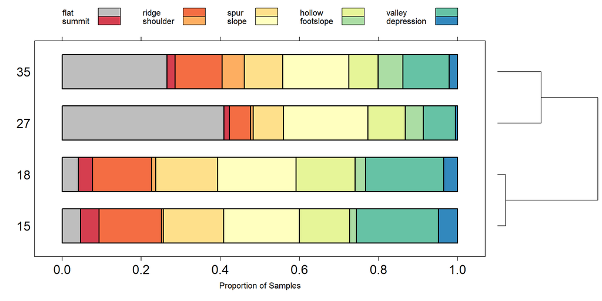

Geomorphon Proportions

| mlra | flat | summit | ridge | shoulder | spur | slope | hollow | footslope | valley | depression |
| --- | --- | --- | --- | --- | --- | --- | --- | --- | --- | --- |
| 15 | 0.047 | 0.047 | 0.158 | 0.004 | 0.153 | 0.191 | 0.127 | 0.017 | 0.207 | 0.048 |
| 18 | 0.041 | 0.035 | 0.150 | 0.011 | 0.157 | 0.198 | 0.149 | 0.026 | 0.198 | 0.035 |
| 27 | 0.409 | 0.014 | 0.053 | 0.007 | 0.076 | 0.214 | 0.094 | 0.046 | 0.081 | 0.005 |
| 35 | 0.265 | 0.020 | 0.119 | 0.056 | 0.097 | 0.167 | 0.074 | 0.063 | 0.117 | 0.021 |

### Landcover Summary

These values are from the [2011 NLCD](https://www.mrlc.gov/nlcd2011.php) (30m) database.

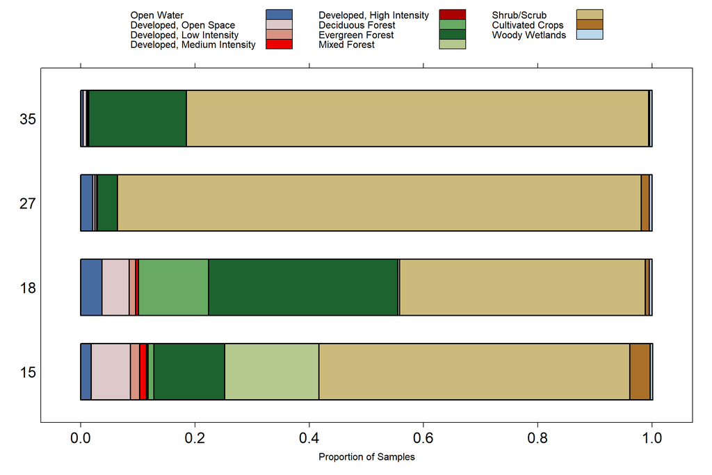

Landcover Proportions

| mlra | Open Water | Developed, Open Space | Developed, Low Intensity | Developed, Medium Intensity | Developed, High Intensity | Deciduous Forest | Evergreen Forest | Mixed Forest | Shrub/Scrub | Cultivated Crops | Woody Wetlands |
| --- | --- | --- | --- | --- | --- | --- | --- | --- | --- | --- | --- |
| 15 | 0.02 | 0.07 | 0.02 | 0.01 | 0 | 0.01 | 0.12 | 0.16 | 0.54 | 0.04 | 0 |
| 18 | 0.04 | 0.05 | 0.01 | 0.00 | 0 | 0.12 | 0.33 | 0.00 | 0.43 | 0.01 | 0 |
| 27 | 0.02 | 0.00 | 0.00 | 0.00 | 0 | 0.00 | 0.04 | 0.00 | 0.92 | 0.01 | 0 |
| 35 | 0.00 | 0.01 | 0.00 | 0.00 | 0 | 0.00 | 0.17 | 0.00 | 0.81 | 0.00 | 0 |

### Multivariate Summary

**Suggested usage:**

- Colors match those used in the density plots above. Be sure to cross-reference this figure with density plots.
- The relative position of points and ellipses are meaningful; absolute position will vary each time the figure is generated.
- Look for “diffuse” vs. “concentrated” clusters: these suggest relatively broadly vs. narrowly defined map unit concepts.
- Nesting of clusters (e.g. smaller cluster contained by larger cluster) suggests superset/subset relationships.
- Overlap is proportional to similarity.

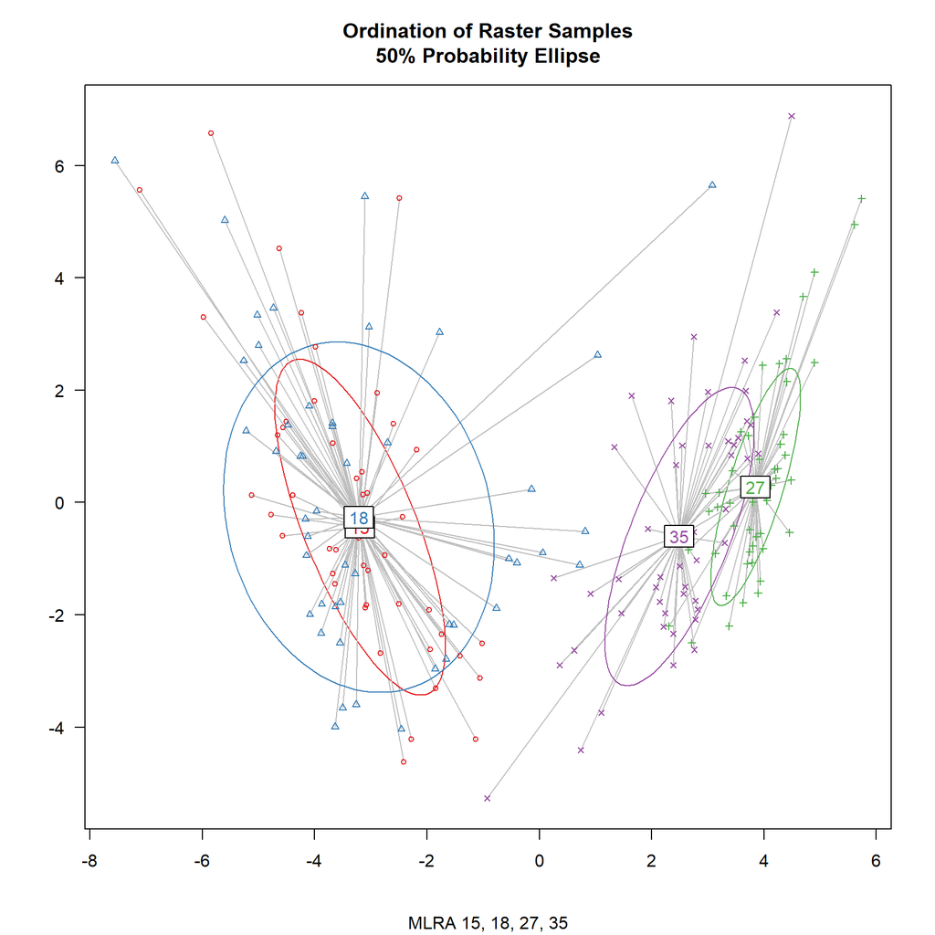

Pair-wise comparisons at the 90% level of confidence.

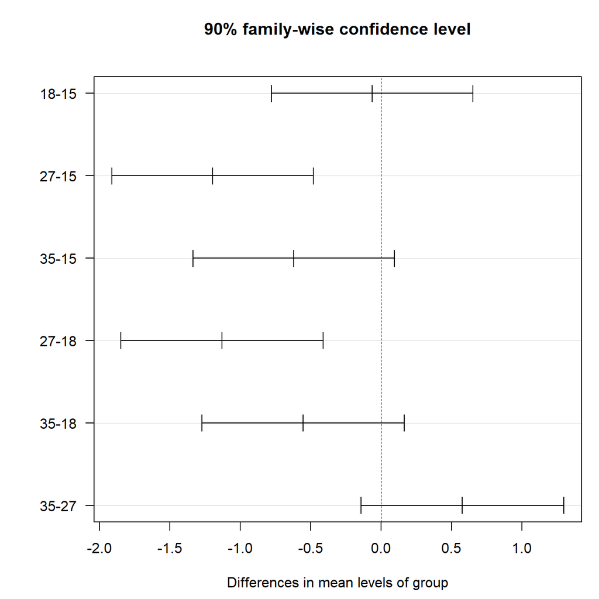

### Raster Data Correlation

The following figure highlights shared information among raster data sources based on [Spearman’s Ranked Correlation coefficient](https://en.wikipedia.org/wiki/Spearman%27s_rank_correlation_coefficient). Branch height is associated with the degree of shared information between raster data.

**Suggested usage:**

- Look for clustered sets of raster data: typically PRISM-derived and elevation data are closely correlated.
- Highly correlated raster data sources reduce the reliability of the “raster data importance” figure.

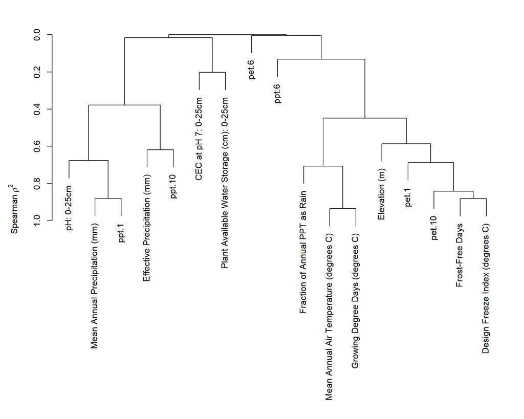

### Raster Data Importance

The following figure ranks raster data sources in terms of how accurately each can be used to discriminate between map unit concepts.

**Suggested usage:**

- Map unit concepts are more consistently predicted (by supervised classification) using those raster data sources with relatively larger “Mean Decrease in Accuracy” values.
- Highly correlated raster data sources will “compete” for positions in this figure. For example, if *elevation* and *mean annual air temperature* are highly correlated, then their respective “importance” values are interchangeable.

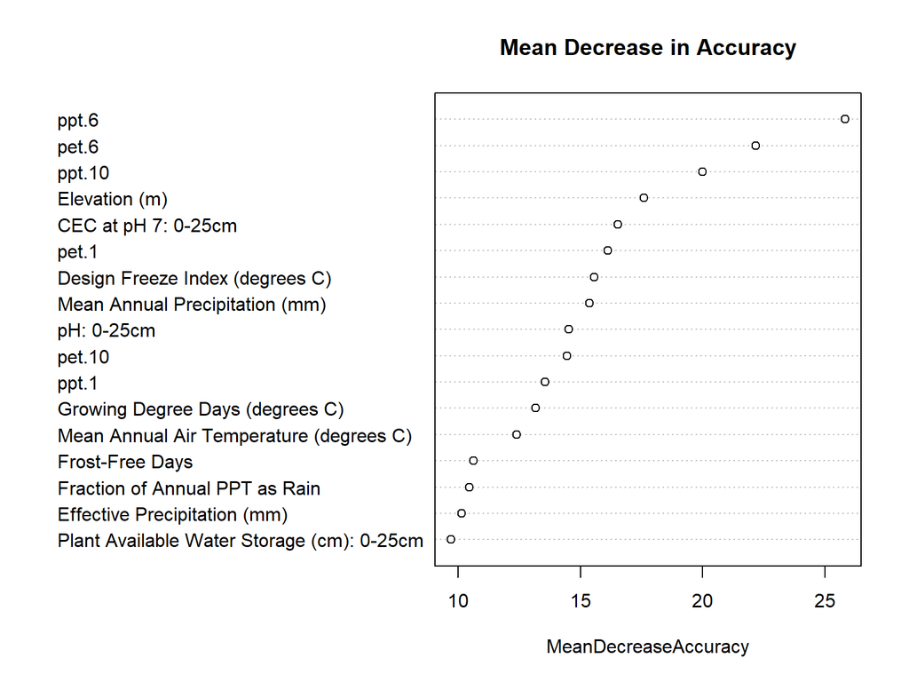

Report [configuration and source code are hosted on GitHub](https://github.com/ncss-tech/soilReports).